# Chaudhary_Homework_6

Jyoti Chaudhary

November 3, 2016

## PROBLEM 1

1. The diamonds dataset is often used to illustrate the ggplot2 package and can be loaded with data(diamonds). Please make a first plot of caret by price, colored by the variable color and using the variable cut to facet_wrap. Please touch up the plot by capitalizing the axes labels and the legend title and by giving an overall title.

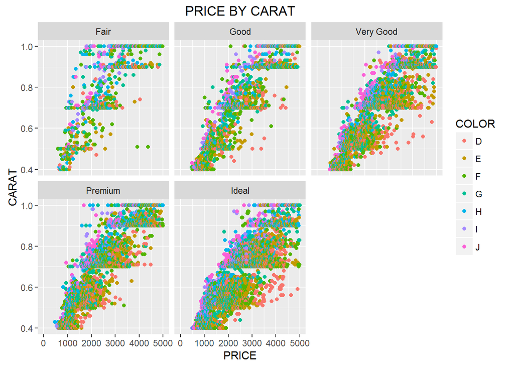

```r
## Loading DIAMONDS dataset into R
data(diamonds)

# Basic plot with capitalized axis and label titles
diamond_plot <- ggplot(diamonds, aes(price, carat, color=color)) + geom_point() + facet_wrap(~cut) + scale_colour_discrete(name = "COLOR") + labs(title="PRICE BY CARAT", y = "CARAT", x = "PRICE")  + ylim(c(0.4,1)) + xlim(c(0,5000))

diamond_plot
```

## PROBLEM 1

After that, please make a total of 6 versions of that same plot using different combinations of themes and color palettes. Your choice as to the combinations.

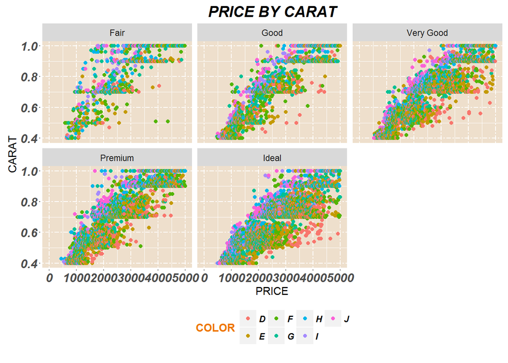

```r
# PLOT 1 --> Panel background set to "antiquewhite2". Axis text converted to Bold & Italic. Legend position change to bottom and direction to Horizontal.

diamond_plot + theme(panel.background = element_rect(fill = "antiquewhite2"), panel.grid.major = element_line(linetype = "twodash"), axis.ticks = element_line(linetype = "dotted"),
    axis.text = element_text(size = 12, face = "bold.italic"),
    plot.title = element_text(size = 15,
        face = "bold.italic"), legend.text = element_text(face = "bold.italic"),
    legend.title = element_text(face = "bold",
        colour = "darkorange2"), legend.position = "bottom",
    legend.direction = "horizontal")
```

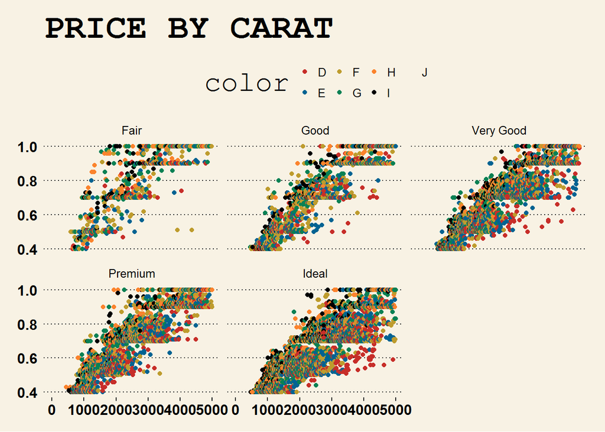

```r
# PLOT 2 --> Wall Street Journal theme applied
diamond_plot + theme_wsj() + scale_color_wsj()
```

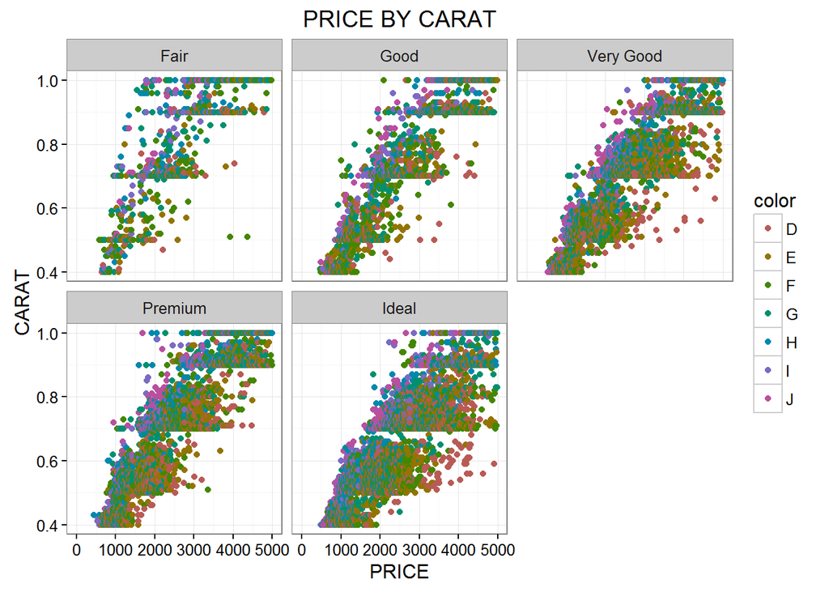

```r
# PLOT 3 --> theme blank and white. chrome = 70 & luminance = 50
diamond_plot + scale_color_hue(c=70, l=50) + theme_bw()
```